# Aula 11: Estrutura de Repetição - Repeat

# Aula 11: Estrutura de Repetição - Repeat

Nesta aula, vamos explorar a estrutura de repetição `repeat`, que é semelhante ao `while`, mas oferece mais flexibilidade em relação à posição da condição de término. Isso significa que podemos avaliar a condição de saída em qualquer ponto do loop, não necessariamente no início.

## Introdução à Estrutura `Repeat`

A estrutura `repeat` é usada para executar instruções um número desconhecido de vezes até que uma condição seja atendida. Ao contrário de outras linguagens de programação que não implementam o `repeat`, no R temos essa estrutura, permitindo que a condição seja testada em qualquer posição dentro do loop.

### Anatomia do Loop `Repeat`

No `repeat`, o código continua executando até que um `break` seja encontrado. O `break` é obrigatório, pois é o que permite sair do loop. Sem ele, o loop continuaria indefinidamente.

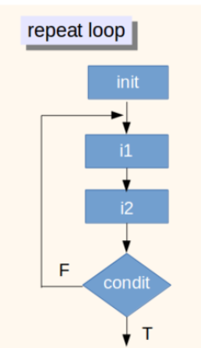

Estrutura Repeat

A estrutura básica do `repeat` em R é a seguinte:

```r
repeat {
  # Procedimento inicial
  if (condicao_salto) next  # Salta para a próxima iteração, opcional
  # Procedimento intermediário
  if (condicao_encerramento) break  # Interrompe o loop
  # Procedimento final
}
```

### Exemplo Simples de `Repeat`

Vamos criar um exemplo simples de `repeat`, onde o loop executa até que uma condição específica seja atendida.

```r
contador <- 1

repeat {
  print(contador)
  contador <- contador + 1
  if (contador > 5) break  # Interrompe o loop quando o contador for maior que 5
}
```

```
[1] 1
[1] 2
[1] 3
[1] 4
[1] 5
```

### Explicação do Código

- **contador <- 1**: Inicia a variável `contador` com o valor 1.
- **repeat { … }**: Inicia o loop que continua indefinidamente até que um `break` seja encontrado.
- **print(contador)**: Exibe o valor do contador em cada iteração.
- **contador <- contador + 1**: Incrementa o valor do contador em 1 a cada iteração.
- **if (contador > 5) break**: Interrompe o loop quando o contador atinge 6.

### Exemplo: Sequência de Fibonacci e Proporção Áurea

Neste exemplo, usaremos o loop `repeat` para calcular quantos termos da sequência de Fibonacci são necessários para que a proporção entre dois números consecutivos se aproxime da Proporção Áurea ($\phi$) com um erro menor que 0,0001.

#### Proporção Áurea

A Proporção Áurea ($\phi$) é dada por:

$$\phi = \frac{1 + \sqrt{5}}{2}$$

Vamos tentar aproximar essa proporção dividindo números consecutivos da sequência de Fibonacci.

```r
N1 <- 1
N2 <- 1

phi <- (1 + sqrt(5))/2  # Valor da Proporção Áurea
erro_maximo <- 1E-4  # Erro máximo permitido

i <- 1  # Inicializa o contador de iterações

repeat {
  N3 <- N1 + N2
  phi_atual <- N3/N2  # Calcula a proporção atual
  teste <- abs(phi_atual - phi) < erro_maximo  # Verifica se o erro é menor que o permitido
  if (teste) break  # Interrompe o loop se a condição for atendida
  i <- i + 1
  N1 <- N2  # Atualiza N1
  N2 <- N3  # Atualiza N2
}

cat("Proporção atual:", phi_atual, "\n")
```

```
Proporção atual: 1.617978
```

```r
cat("Erro:", phi_atual - phi, "\n")
```

```
Erro: -5.646066e-05
```

```r
cat("Número de termos necessários:", i, "\n")
```

```
Número de termos necessários: 10
```

### Explicação do Código

- **N1, N2**: São os primeiros números da sequência de Fibonacci.
- **phi**: É o valor da Proporção Áurea.
- **erro_maximo**: Define a precisão desejada.
- **repeat { … }**: Continua até que a diferença entre `phi_atual` e `phi` seja menor que o erro máximo permitido.
- **if (teste) break**: Interrompe o loop quando o erro é suficientemente pequeno.

### Exemplo Prático: Cálculo do Raiz Quadrada por Aproximação

Neste exemplo, vamos usar o loop `repeat` para calcular a raiz quadrada de um número usando o método de Newton-Raphson, que é um método iterativo para encontrar aproximações sucessivas.

```r
numero <- 25  # Número do qual queremos calcular a raiz quadrada
aproximacao <- numero / 2  # Primeira aproximação
erro_maximo <- 1E-6  # Precisão desejada

repeat {
  raiz <- 0.5 * (aproximacao + numero / aproximacao)  # Fórmula de Newton-Raphson
  if (abs(raiz - aproximacao) < erro_maximo) break  # Interrompe se o erro for menor que o máximo
  aproximacao <- raiz  # Atualiza a aproximação
}

cat("Aproximação da raiz quadrada de", numero, ":", raiz, "\n")
```

```
Aproximação da raiz quadrada de 25 : 5
```

### Exemplo Prático: Estimando o Tempo de Crescimento Populacional

Neste exemplo, vamos usar o loop `repeat` para calcular quanto tempo levará para uma população dobrar, dado uma taxa de crescimento anual.

```r
populacao_inicial <- 500  # População inicial
taxa_crescimento <- 0.05  # Taxa de crescimento de 5% ao ano
populacao_desejada <- 1000  # População alvo

anos <- 0  # Contador de anos
populacao <- populacao_inicial

repeat {
  populacao <- populacao * (1 + taxa_crescimento)  # Atualiza a população
  anos <- anos + 1
  if (populacao >= populacao_desejada) break  # Interrompe o loop quando a população atingir a desejada
}

cat("Número de anos necessários para dobrar a população:", anos, "\n")
```

```
Número de anos necessários para dobrar a população: 15
```

### Explicação dos Exemplos

- **Newton-Raphson**: É um método iterativo que converge rapidamente para a solução, neste caso, a raiz quadrada do número.
- **Crescimento Populacional**: Simula o tempo necessário para que uma população dobre de tamanho, considerando uma taxa de crescimento anual.

## Conclusão

A estrutura de repetição `repeat` é poderosa e flexível, permitindo que você execute loops até que uma condição específica seja atendida. É especialmente útil em situações onde o número de iterações não pode ser previsto com antecedência. Nesta aula, vimos como aplicar `repeat` para resolver problemas que exigem um número variável de iterações, como o cálculo da Proporção Áurea e a aproximação de raízes quadradas.